# Master Thesis: A Causal Test of the Law of 1/n and its Mechanisms – Analysis: Conventional Regressions

Florian Fox

2022-10-21

# Load data and packages

```r
time <- Sys.time()
library(tidyverse)
library(fixest)
#library(rdrobust)
#library(rdmulti)
#library(rddensity)
#library(rdd) # For the McCrary (2008) test
library(xtable)
#library(scales)
#library(janitor)
source("functions/functions.R")
```

```r
data <-
  readRDS("data/gemeinderatswahlen_alldata.rds") %>%
  mutate(
    year = as.factor(year),
    ags = as.factor(ags)
  )
```

Generating different data sets:

```r
d_bivariate <- data %>%
  select(ln_gross_expenditure_pc, total_seats, ags, year, state) %>% drop_na()
d_bivariate_iv <- data %>%
  select(ln_gross_expenditure_pc, total_seats, ags, year, total_seats_24_y_ago) %>% drop_na()
# d_rdd_bivariate <- data %>%
#   select(ln_gross_expenditure_pc, total_seats, inhabs_rel_to_cutoff, above_cutoff, inhabitants_treshold_factor, inhabitants_treshold, year, ags, election_year, state, closest, clean_disc_acc_Höhmann, clean_disc_acc_to_my_research) %>%
#   drop_na(ln_gross_expenditure_pc, total_seats, inhabs_rel_to_cutoff) %>%
#   # Repeat (bandwidth) window calculation for data subsets
#   mutate(
#     closest = base::rank(abs(inhabs_rel_to_cutoff), ties.method = "last"),
#     closest = closest/max(closest),
#   )

d_controls <- data %>%
  select(ln_gross_expenditure_pc, total_seats, ags, year, inh_tot, pop_over65, unempl_rate, total_area_ha,
    share_working_age, kreisfreie_stadt, stadt, years_since_last_elec, state) %>%
  drop_na()
d_controls_iv <- data %>%
  select(ln_gross_expenditure_pc, total_seats, ags, year, total_seats_24_y_ago, inh_tot, pop_over65,
         unempl_rate, total_area_ha, share_working_age, kreisfreie_stadt, stadt,
         years_since_last_elec) %>%
  drop_na()
# d_rdd <- data %>%
#   select(ln_gross_expenditure_pc, total_seats, inhabs_rel_to_cutoff, above_cutoff, closest,
#          inhabitants_treshold_factor, year, ags, state,
#          inh_tot, pop_over65, unempl_rate, total_area_ha,
#          share_working_age, kreisfreie_stadt, stadt, years_since_last_elec) %>%
#   drop_na() %>%
#   # Repeat (bandwidth) window calculation for data subsets
#   mutate(
#     closest = base::rank(abs(inhabs_rel_to_cutoff), ties.method = "last"),
#     closest = closest/max(closest),
#   )
# d_ttest <- data %>%
#   select(ln_gross_expenditure_pc, inhabs_rel_to_cutoff) %>% drop_na()
```

# OLS regression

**Biases in OLS regression**

“However, this regression potentially suffers from reverse causality as well as omitted variable bias. Reverse causality may arise from the fact that a municipality with a larger public budget faces more complex budget negotiations and hence may need more councilors ([Pettersson-Lidbom, 2012](https://doi.org/10.1016/j.jpubeco.2011.07.004), p. 269). If this is indeed the case, one would expect β to overestimate the true causal effect of council size. Omitted variable bias may also be at play because even with a large number of control variables one can not completely rule out confounders ([Höhmann, 2017](https://doi.org/10.1007/s11127-017-0484-2), p. 347). Depending on the sign of the association with council size and public spending, this bias could go either way. More precisely, if voters who prefer a larger number of councilors also want higher spending, the relationship between council size and government size might be spuriously correlated ([Egger & Koethenbuerger, 2010](https://www.doi.org/10.1257/app.2.4.200), pp. 201, 204), again resulting in an overestimate of the true effect.”

(Citation from my project study)

First, show the general association of population and council size, respectively, with spending.

```r
# population as independent variable
fixest::feols(ln_gross_expenditure_pc ~ sw0(poly(inh_tot, 1), poly(inh_tot, 2),
                                            poly(inh_tot, 3), poly(inh_tot, 4),
                                            poly(inh_tot, 5), poly(inh_tot, 6)),
              vcov = "hetero", # heteroskedasticity-robust SEs
              data = data %>% drop_na(inh_tot, ln_gross_expenditure_pc))
```

```
## Standard-errors: Heteroskedasticity-robust
## Expl. vars.: 1
##             Estimate Std. Error t value  Pr(>|t|)
## (Intercept)   7.1892   0.001259 5709.96 < 2.2e-16 ***
## ---
## Expl. vars.: poly(inh_tot, 1)
##                  Estimate Std. Error   t value  Pr(>|t|)
## (Intercept)       7.18920   0.001232 5836.1454 < 2.2e-16 ***
## poly(inh_tot, 1) 28.77817   1.590721   18.0913 < 2.2e-16 ***
## ---
## Expl. vars.: poly(inh_tot, 2)
##                    Estimate Std. Error   t value  Pr(>|t|)
## (Intercept)         7.18920   0.001215 5917.9827 < 2.2e-16 ***
## poly(inh_tot, 2)1  28.77817   1.141811   25.2040 < 2.2e-16 ***
## poly(inh_tot, 2)2 -22.56290   1.500952  -15.0324 < 2.2e-16 ***
## ---
## Expl. vars.: poly(inh_tot, 3)
##                    Estimate Std. Error   t value  Pr(>|t|)
## (Intercept)         7.18920   0.001201 5988.3397 < 2.2e-16 ***
## poly(inh_tot, 3)1  28.77817   0.757869   37.9725 < 2.2e-16 ***
## poly(inh_tot, 3)2 -22.56290   0.873635  -25.8265 < 2.2e-16 ***
## poly(inh_tot, 3)3  20.52093   0.846533   24.2412 < 2.2e-16 ***
## ---
## Expl. vars.: poly(inh_tot, 4)
##                    Estimate Std. Error   t value  Pr(>|t|)
## (Intercept)         7.18920   0.001194 6019.9499 < 2.2e-16 ***
## poly(inh_tot, 4)1  28.77817   0.770313   37.3591 < 2.2e-16 ***
## poly(inh_tot, 4)2 -22.56290   0.979110  -23.0443 < 2.2e-16 ***
## poly(inh_tot, 4)3  20.52093   0.832467   24.6507 < 2.2e-16 ***
## poly(inh_tot, 4)4 -13.58283   1.209348  -11.2315 < 2.2e-16 ***
## ---
## Expl. vars.: poly(inh_tot, 5)
##                    Estimate Std. Error   t value  Pr(>|t|)
## (Intercept)         7.18920   0.001189 6046.2090 < 2.2e-16 ***
## poly(inh_tot, 5)1  28.77817   0.561157   51.2836 < 2.2e-16 ***
## poly(inh_tot, 5)2 -22.56290   0.749385  -30.1085 < 2.2e-16 ***
## poly(inh_tot, 5)3  20.52093   0.596054   34.4280 < 2.2e-16 ***
## poly(inh_tot, 5)4 -13.58283   0.891384  -15.2379 < 2.2e-16 ***
## poly(inh_tot, 5)5  12.29197   0.796758   15.4275 < 2.2e-16 ***
## ---
## Expl. vars.: poly(inh_tot, 6)
##                    Estimate Std. Error   t value  Pr(>|t|)
## (Intercept)         7.18920   0.001187 6057.3944 < 2.2e-16 ***
## poly(inh_tot, 6)1  28.77817   0.376696   76.3962 < 2.2e-16 ***
## poly(inh_tot, 6)2 -22.56290   0.433387  -52.0618 < 2.2e-16 ***
## poly(inh_tot, 6)3  20.52093   0.399265   51.3968 < 2.2e-16 ***
## poly(inh_tot, 6)4 -13.58283   0.575484  -23.6025 < 2.2e-16 ***
## poly(inh_tot, 6)5  12.29197   0.447546   27.4653 < 2.2e-16 ***
## poly(inh_tot, 6)6  -7.99083   0.597134  -13.3820 < 2.2e-16 ***
```

```r
# council size as independent variable
fixest::feols(ln_gross_expenditure_pc ~ sw0(poly(total_seats, 1), poly(total_seats, 2),
                                            poly(total_seats, 3), poly(total_seats, 4),
                                            poly(total_seats, 5), poly(total_seats, 6)),
              vcov = "hetero", # heteroskedasticity-robust SEs
              data = d_bivariate)
```

```
## Standard-errors: Heteroskedasticity-robust
## Expl. vars.: 1
##             Estimate Std. Error t value  Pr(>|t|)
## (Intercept)  7.18909   0.001278  5627.2 < 2.2e-16 ***
## ---
## Expl. vars.: poly(total_seats, 1)
##                      Estimate Std. Error  t value  Pr(>|t|)
## (Intercept)           7.18909   0.001203 5975.425 < 2.2e-16 ***
## poly(total_seats, 1) 46.20640   0.354830  130.221 < 2.2e-16 ***
## ---
## Expl. vars.: poly(total_seats, 2)
##                       Estimate Std. Error   t value  Pr(>|t|)
## (Intercept)            7.18909   0.001201 5984.6151 < 2.2e-16 ***
## poly(total_seats, 2)1 46.20640   0.369154  125.1683 < 2.2e-16 ***
## poly(total_seats, 2)2 -7.17665   0.433410  -16.5586 < 2.2e-16 ***
## ---
## Expl. vars.: poly(total_seats, 3)
##                       Estimate Std. Error   t value  Pr(>|t|)
## (Intercept)            7.18909   0.001197 6007.7091 < 2.2e-16 ***
## poly(total_seats, 3)1 46.20640   0.374063  123.5258 < 2.2e-16 ***
## poly(total_seats, 3)2 -7.17665   0.482156  -14.8845 < 2.2e-16 ***
## poly(total_seats, 3)3 11.32019   0.606309   18.6707 < 2.2e-16 ***
## ---
## Expl. vars.: poly(total_seats, 4)
##                       Estimate Std. Error   t value  Pr(>|t|)
## (Intercept)            7.18909   0.001194 6021.9187 < 2.2e-16 ***
## poly(total_seats, 4)1 46.20640   0.356414  129.6424 < 2.2e-16 ***
## poly(total_seats, 4)2 -7.17665   0.385586  -18.6123 < 2.2e-16 ***
## poly(total_seats, 4)3 11.32019   0.453399   24.9674 < 2.2e-16 ***
## poly(total_seats, 4)4 -8.84166   0.548662  -16.1150 < 2.2e-16 ***
## ---
## Expl. vars.: poly(total_seats, 5)
##                        Estimate Std. Error    t value  Pr(>|t|)
## (Intercept)            7.189092   0.001194 6022.04292 < 2.2e-16 ***
## poly(total_seats, 5)1 46.206400   0.358104  129.03058 < 2.2e-16 ***
## poly(total_seats, 5)2 -7.176651   0.395417  -18.14960 < 2.2e-16 ***
## poly(total_seats, 5)3 11.320194   0.467283   24.22556 < 2.2e-16 ***
## poly(total_seats, 5)4 -8.841665   0.561401  -15.74930 < 2.2e-16 ***
## poly(total_seats, 5)5 -0.912702   0.736168   -1.23980   0.21505
## ---
## Expl. vars.: poly(total_seats, 6)
##                        Estimate Std. Error    t value  Pr(>|t|)
## (Intercept)            7.189092   0.001191 6037.36484 < 2.2e-16 ***
## poly(total_seats, 6)1 46.206400   0.360780  128.07352 < 2.2e-16 ***
## poly(total_seats, 6)2 -7.176651   0.419764  -17.09686 < 2.2e-16 ***
## poly(total_seats, 6)3 11.320194   0.476497   23.75709 < 2.2e-16 ***
## poly(total_seats, 6)4 -8.841665   0.548233  -16.12756 < 2.2e-16 ***
## poly(total_seats, 6)5 -0.912702   0.713119   -1.27987   0.20059
## poly(total_seats, 6)6  9.146508   0.842673   10.85417 < 2.2e-16 ***
```

Running multivariate regressions:

```r
# Adding variables stepwise using the `csw` function
fixest::feols(
  ln_gross_expenditure_pc ~ csw0(total_seats, inh_tot, pop_over65, unempl_rate, total_area_ha,
    share_working_age, kreisfreie_stadt, stadt, years_since_last_elec),
  vcov = "hetero",
  data = data
)
```

```
## NOTE: 121,429 observations removed because of NA values (LHS: 121,429). [This msg only concerns the variables common to all estimations.]
```

```
## Variables 'years_since_last_elec6', 'years_since_last_elec7' and 6 others have been removed because of collinearity (see $collin.var).
```

```
## Standard-errors: Heteroskedasticity-robust
## Expl. vars.: 1
##             Estimate Std. Error t value  Pr(>|t|)
## (Intercept)   7.1892   0.001259 5709.96 < 2.2e-16 ***
## ---
## Expl. vars.: total_seats
##             Estimate Std. Error  t value  Pr(>|t|)
## (Intercept) 6.946845   0.002524 2752.108 < 2.2e-16 ***
## total_seats 0.015198   0.000117  130.221 < 2.2e-16 ***
## ---
## Expl. vars.: total_seats + inh_tot
##                Estimate   Std. Error    t value  Pr(>|t|)
## (Intercept) 6.954496009 0.0028304477 2457.03042 < 2.2e-16 ***
## total_seats 0.014562674 0.0001491632   97.62913 < 2.2e-16 ***
## inh_tot     0.000000358 0.0000000424    8.45526 < 2.2e-16 ***
## ---
## Expl. vars.: total_seats + inh_tot + pop_over65
##                Estimate   Std. Error    t value  Pr(>|t|)
## (Intercept) 6.952900650 0.0070609474 984.697976 < 2.2e-16 ***
## total_seats 0.014576418 0.0001462888  99.641361 < 2.2e-16 ***
## inh_tot     0.000000354 0.0000000419   8.450278 < 2.2e-16 ***
## pop_over65  0.008113986 0.0345828034   0.234625    0.8145
## ---
## Expl. vars.: total_seats + inh_tot + pop_over65 + unempl_rate
##                 Estimate   Std. Error    t value  Pr(>|t|)
## (Intercept)  7.005952360 0.0069660420 1005.72927 < 2.2e-16 ***
## total_seats  0.014930389 0.0001539811   96.96246 < 2.2e-16 ***
## inh_tot      0.000000577 0.0000000585    9.85742 < 2.2e-16 ***
## pop_over65   0.434483600 0.0348808034   12.45624 < 2.2e-16 ***
## unempl_rate -2.812315316 0.0367992971  -76.42307 < 2.2e-16 ***
## ---
## Expl. vars.: total_seats + inh_tot + pop_over65 + unempl_rate + total_area_ha
##                   Estimate   Std. Error    t value     Pr(>|t|)
## (Intercept)    7.019679951 0.0069191567 1014.52826    < 2.2e-16 ***
## total_seats    0.010839401 0.0001834511   59.08606    < 2.2e-16 ***
## inh_tot        0.000000261 0.0000000568    4.59962 0.0000042375 ***
## pop_over65     0.447265268 0.0346559476   12.90587    < 2.2e-16 ***
## unempl_rate   -2.876928692 0.0368064191  -78.16378    < 2.2e-16 ***
## total_area_ha  0.000019955 0.0000005125   38.93944    < 2.2e-16 ***
## ---
```

[output cut: 58 more lines]

```
##                                    Pr(>|t|)
## (Intercept)                       < 2.2e-16 ***
## total_seats                       < 2.2e-16 ***
## inh_tot                0.000001755548785227 ***
## pop_over65             0.000000002822499615 ***
## unempl_rate                       < 2.2e-16 ***
## total_area_ha                     < 2.2e-16 ***
## share_working_age      0.410803147835743121
## kreisfreie_stadt1                 < 2.2e-16 ***
## stadt1                            < 2.2e-16 ***
## years_since_last_elec1            < 2.2e-16 ***
## years_since_last_elec2 0.000000000602758365 ***
## years_since_last_elec3            < 2.2e-16 ***
## years_since_last_elec4 0.000000000000010705 ***
## years_since_last_elec5            < 2.2e-16 ***
```

```r
ols <- fixest::feols(
  ln_gross_expenditure_pc ~ total_seats + inh_tot + pop_over65 + unempl_rate + total_area_ha +
    share_working_age + kreisfreie_stadt + stadt + years_since_last_elec,
  vcov = "hetero",
  data = d_controls
)
```

```
## Variables 'years_since_last_elec6', 'years_since_last_elec7' and 6 others have been removed because of collinearity (see $collin.var).
```

```r
summary(ols, n = 20)
```

```
## OLS estimation, Dep. Var.: ln_gross_expenditure_pc
## Observations: 105,186
## Standard-errors: Heteroskedasticity-robust
##                            Estimate   Std. Error    t value
## (Intercept)             7.131532325 0.0402986929 176.966840
## total_seats             0.008098496 0.0001898797  42.650655
## inh_tot                -0.000000192 0.0000000402  -4.779973
## pop_over65              0.267054907 0.0449427377   5.942115
## unempl_rate            -2.931558971 0.0410825567 -71.357754
## total_area_ha           0.000016821 0.0000004979  33.786935
## share_working_age      -0.046782499 0.0568794991  -0.822484
## kreisfreie_stadt1       0.413850412 0.0105396117  39.266192
## stadt1                  0.126901527 0.0032667663  38.846222
## years_since_last_elec1 -0.035187786 0.0037821500  -9.303646
## years_since_last_elec2 -0.023325890 0.0037681440  -6.190286
## years_since_last_elec3 -0.038936139 0.0034649841 -11.237033
## years_since_last_elec4 -0.027387905 0.0035422868  -7.731702
## years_since_last_elec5  0.201146038 0.0057412881  35.035002
##                                    Pr(>|t|)
## (Intercept)                       < 2.2e-16 ***
## total_seats                       < 2.2e-16 ***
## inh_tot                0.000001755548785227 ***
## pop_over65             0.000000002822499615 ***
## unempl_rate                       < 2.2e-16 ***
## total_area_ha                     < 2.2e-16 ***
## share_working_age      0.410803147835743121
## kreisfreie_stadt1                 < 2.2e-16 ***
## stadt1                            < 2.2e-16 ***
## years_since_last_elec1            < 2.2e-16 ***
## years_since_last_elec2 0.000000000602758365 ***
## years_since_last_elec3            < 2.2e-16 ***
## years_since_last_elec4 0.000000000000010705 ***
## years_since_last_elec5            < 2.2e-16 ***
## ... 8 variables were removed because of collinearity (years_since_last_elec6, years_since_last_elec7 and 6 others [full set in $collin.var])
## ---
## Signif. codes:  0 '***' 0.001 '**' 0.01 '*' 0.05 '.' 0.1 ' ' 1
## RMSE: 0.367461   Adj. R2: 0.200008
```

```r
# Main model with Bavarian data only:
fixest::feols(
  ln_gross_expenditure_pc ~ total_seats + inh_tot + pop_over65 + unempl_rate + total_area_ha +
    share_working_age + kreisfreie_stadt + stadt + years_since_last_elec,
  vcov = "hetero",
  data = d_controls %>% filter(state == 9)
)
```

```
## Variables 'years_since_last_elec6', 'years_since_last_elec7' and 6 others have been removed because of collinearity (see $collin.var).
```

```
## OLS estimation, Dep. Var.: ln_gross_expenditure_pc
## Observations: 26,728
## Standard-errors: Heteroskedasticity-robust
##                       Estimate   Std. Error    t value   Pr(>|t|)
## (Intercept)        7.249480704 0.0998991471  72.567994  < 2.2e-16 ***
## total_seats        0.000137195 0.0005285734   0.259558 0.79520706
## inh_tot            0.000000419 0.0000000324  12.941545  < 2.2e-16 ***
## pop_over65         2.060043902 0.0946362545  21.768020  < 2.2e-16 ***
## unempl_rate       -5.383512042 0.1142239331 -47.131209  < 2.2e-16 ***
## total_area_ha     -0.000003043 0.0000009068  -3.355303 0.00079389 ***
## share_working_age -0.004593055 0.1444577449  -0.031795 0.97463565
## kreisfreie_stadt1  0.519322554 0.0202557211  25.638315  < 2.2e-16 ***
## ... 6 coefficients remaining (display them with summary() or use argument n)
## ... 8 variables were removed because of collinearity (years_since_last_elec6, years_since_last_elec7 and 6 others [full set in $collin.var])
## ---
## Signif. codes:  0 '***' 0.001 '**' 0.01 '*' 0.05 '.' 0.1 ' ' 1
## RMSE: 0.306685   Adj. R2: 0.128636
```

```r
# Adding "political" variables
ols_pol <- fixest::feols(
  ln_gross_expenditure_pc ~ total_seats + inh_tot + pop_over65 + unempl_rate + total_area_ha +
    share_working_age + kreisfreie_stadt + stadt + turnout + ward_elections + const_typ_sueddt +
    years_since_last_elec,
  vcov = "hetero",
  data = data
)
```

```
## NOTE: 185,292 observations removed because of NA values (LHS: 121,429, RHS: 132,531).
```

```r
summary(ols_pol, n = 25)
```

```
## OLS estimation, Dep. Var.: ln_gross_expenditure_pc
## Observations: 46,641
## Standard-errors: Heteroskedasticity-robust
##                           Estimate   Std. Error   t value          Pr(>|t|)
## (Intercept)             7.44872773 0.0820088205  90.82837         < 2.2e-16 ***
## total_seats            -0.00224337 0.0003546652  -6.32531 0.000000000255012 ***
## inh_tot                 0.00000101 0.0000000815  12.38139         < 2.2e-16 ***
## pop_over65              1.91171025 0.0701134812  27.26594         < 2.2e-16 ***
## unempl_rate            -4.23541264 0.1043315839 -40.59569         < 2.2e-16 ***
## total_area_ha          -0.00000617 0.0000005134 -12.01689         < 2.2e-16 ***
## share_working_age       0.11695681 0.1056700826   1.10681 0.268381348918325
## kreisfreie_stadt1       0.52983562 0.0148265210  35.73567         < 2.2e-16 ***
## stadt1                  0.10390049 0.0037599490  27.63348         < 2.2e-16 ***
## turnout                -0.19219796 0.0168576931 -11.40120         < 2.2e-16 ***
## ward_elections          0.07178390 0.0060959120  11.77574         < 2.2e-16 ***
## const_typ_sueddt       -0.12362468 0.0327036403  -3.78015 0.000156928824838 ***
## years_since_last_elec1 -0.02732288 0.0043832154  -6.23353 0.000000000459949 ***
## years_since_last_elec2 -0.02570255 0.0045606841  -5.63568 0.000000017537558 ***
## years_since_last_elec3 -0.04078956 0.0041068294  -9.93213         < 2.2e-16 ***
## years_since_last_elec4 -0.02742005 0.0041241272  -6.64869 0.000000000029896 ***
## years_since_last_elec5  0.00714282 0.0058149321   1.22836 0.219318563730727
## ---
## Signif. codes:  0 '***' 0.001 '**' 0.01 '*' 0.05 '.' 0.1 ' ' 1
## RMSE: 0.286193   Adj. R2: 0.147615
```

```r
# Only Bavarian data:
ols_pol <- fixest::feols(
  ln_gross_expenditure_pc ~ total_seats + inh_tot + pop_over65 + unempl_rate + total_area_ha +
    share_working_age + kreisfreie_stadt + stadt + turnout + ward_elections + const_typ_sueddt +
    years_since_last_elec +
    no_parties_in_parliament + absolute_majority + cdu_csu_majority + spd_majority +
    waehlergruppen_majority + cdu_csu_mayor + spd_mayor,
  vcov = "hetero",
  data = data
)
```

```
## NOTE: 205,205 observations removed because of NA values (LHS: 121,429, RHS: 194,925).
```

```
## The variable 'const_typ_sueddt' has been removed because of collinearity (see $collin.var).
```

```r
summary(ols_pol, n = 25)
```

```
## OLS estimation, Dep. Var.: ln_gross_expenditure_pc
## Observations: 26,728
## Standard-errors: Heteroskedasticity-robust
##                               Estimate   Std. Error    t value   Pr(>|t|)
## (Intercept)               7.7851013409 0.1009441980  77.122821  < 2.2e-16 ***
## total_seats              -0.0070255198 0.0006944038 -10.117340  < 2.2e-16 ***
## inh_tot                   0.0000005526 0.0000000377  14.670300  < 2.2e-16 ***
## pop_over65                1.8276062814 0.0960965083  19.018446  < 2.2e-16 ***
## unempl_rate              -5.0460054968 0.1172021379 -43.053869  < 2.2e-16 ***
## total_area_ha             0.0000000977 0.0000009358   0.104424 0.91683351
## share_working_age        -0.1905941419 0.1440442242  -1.323164 0.18579215
## kreisfreie_stadt1         0.5733321431 0.0208546367  27.491831  < 2.2e-16 ***
## stadt1                    0.0655950647 0.0058870684  11.142229  < 2.2e-16 ***
## turnout                  -0.4747992759 0.0275743969 -17.218845  < 2.2e-16 ***
## years_since_last_elec1   -0.0180201631 0.0061053273  -2.951547 0.00316461 **
## years_since_last_elec2   -0.0032415736 0.0065329210  -0.496191 0.61976407
## years_since_last_elec3   -0.0185601993 0.0062095031  -2.988999 0.00280148 **
## years_since_last_elec4   -0.0176865233 0.0061301708  -2.885160 0.00391528 **
## years_since_last_elec5   -0.0016165956 0.0062908944  -0.256974 0.79720091
## no_parties_in_parliament  0.0114357228 0.0029721506   3.847626 0.00011955 ***
## absolute_majority        -0.0169977107 0.0072058454  -2.358878 0.01833744 *
## cdu_csu_majority          0.0271931303 0.0093082898   2.921388 0.00348767 **
## spd_majority             -0.0357195494 0.0313767046  -1.138410 0.25495960
## waehlergruppen_majority   0.0258577501 0.0070184881   3.684234 0.00022984 ***
## cdu_csu_mayor             0.0072723568 0.0048232269   1.507778 0.13162312
## spd_mayor                 0.0213201929 0.0065798557   3.240222 0.00119583 **
## ... 1 variable was removed because of collinearity (const_typ_sueddt)
## ---
## Signif. codes:  0 '***' 0.001 '**' 0.01 '*' 0.05 '.' 0.1 ' ' 1
## RMSE: 0.30491   Adj. R2: 0.138437
```

```r
rm(ols_pol)
```

# Panel regression

Ignoring the potential issue of bad controls, I am running some panel regressions with year and municipality as fixed effects.

## Bivariate-regression FE models

Association of population and council size, respectively, with spending in the FE case.

```r
# population as independent variable
reg <- fixest::feols(ln_gross_expenditure_pc ~ sw0(poly(inh_tot, 1), poly(inh_tot, 2),
                                                   poly(inh_tot, 3), poly(inh_tot, 4),
                                                   poly(inh_tot, 5), poly(inh_tot, 6)) |
                       year + ags,
                     data = data %>% drop_na(inh_tot, ln_gross_expenditure_pc))
summary(reg, vcov = "hetero")
```

```
## Standard-errors: Heteroskedasticity-robust
## Expl. vars.: 1
## No variable (only the fixed-effects).
## ---
## Expl. vars.: poly(inh_tot, 1)
##                  Estimate Std. Error  t value      Pr(>|t|)
## poly(inh_tot, 1) -28.0522     5.5157 -5.08588 0.00000036659 ***
## ---
## Expl. vars.: poly(inh_tot, 2)
##                   Estimate Std. Error  t value  Pr(>|t|)
## poly(inh_tot, 2)1 -90.4577    9.46258 -9.55953 < 2.2e-16 ***
## poly(inh_tot, 2)2  19.5582    2.37812  8.22424 < 2.2e-16 ***
## ---
## Expl. vars.: poly(inh_tot, 3)
##                   Estimate Std. Error   t value          Pr(>|t|)
## poly(inh_tot, 3)1 -95.8319    9.31661 -10.28614         < 2.2e-16 ***
## poly(inh_tot, 3)2  50.9799    5.52713   9.22357         < 2.2e-16 ***
## poly(inh_tot, 3)3 -13.9658    2.14515  -6.51040 0.000000000075304 ***
## ---
## Expl. vars.: poly(inh_tot, 4)
##                    Estimate Std. Error   t value         Pr(>|t|)
## poly(inh_tot, 4)1 -93.06522    9.04657 -10.28735        < 2.2e-16 ***
## poly(inh_tot, 4)2  49.88989    5.37435   9.28296        < 2.2e-16 ***
## poly(inh_tot, 4)3 -31.46338    4.98987  -6.30546 0.00000000028854 ***
## poly(inh_tot, 4)4   7.84114    1.99189   3.93654 0.00008272008115 ***
## ---
## Expl. vars.: poly(inh_tot, 5)
##                    Estimate Std. Error  t value            Pr(>|t|)
## poly(inh_tot, 5)1 -80.39229    9.20164 -8.73674           < 2.2e-16 ***
## poly(inh_tot, 5)2  56.19523    5.26702 10.66927           < 2.2e-16 ***
## poly(inh_tot, 5)3 -46.19045    5.61158 -8.23128           < 2.2e-16 ***
## poly(inh_tot, 5)4  20.99529    2.84396  7.38240 0.00000000000015665 ***
## poly(inh_tot, 5)5  -7.80917    1.08441 -7.20129 0.00000000000060059 ***
## ---
## Expl. vars.: poly(inh_tot, 6)
##                    Estimate Std. Error  t value               Pr(>|t|)
## poly(inh_tot, 6)1 -75.52609    9.34476 -8.08218 0.00000000000000064316 ***
## poly(inh_tot, 6)2  65.89574    5.74881 11.46250              < 2.2e-16 ***
## poly(inh_tot, 6)3 -41.23345    5.75858 -7.16035 0.00000000000081017726 ***
## poly(inh_tot, 6)4  25.98503    3.22109  8.06715 0.00000000000000072740 ***
## poly(inh_tot, 6)5 -22.36652    3.40916 -6.56071 0.00000000005380877465 ***
## poly(inh_tot, 6)6   7.09022    1.38732  5.11075 0.00000032146941305095 ***
```

```r
summary(reg, vcov = "twoway")
```

```
## Standard-errors: Clustered (year & ags)
## Expl. vars.: 1
## No variable (only the fixed-effects).
## ---
## Expl. vars.: poly(inh_tot, 1)
##                  Estimate Std. Error  t value Pr(>|t|)
## poly(inh_tot, 1) -28.0522     12.809 -2.19003 0.049005 *
## ---
## Expl. vars.: poly(inh_tot, 2)
##                   Estimate Std. Error  t value   Pr(>|t|)
## poly(inh_tot, 2)1 -90.4577   17.03683 -5.30954 0.00018543 ***
## poly(inh_tot, 2)2  19.5582    4.04234  4.83834 0.00040619 ***
## ---
## Expl. vars.: poly(inh_tot, 3)
##                   Estimate Std. Error  t value    Pr(>|t|)
## poly(inh_tot, 3)1 -95.8319   15.98927 -5.99352 0.000062789 ***
## poly(inh_tot, 3)2  50.9799    9.74151  5.23326 0.000210088 ***
## poly(inh_tot, 3)3 -13.9658    3.52899 -3.95744 0.001902090 **
## ---
## Expl. vars.: poly(inh_tot, 4)
##                    Estimate Std. Error  t value   Pr(>|t|)
## poly(inh_tot, 4)1 -93.06522   15.57992 -5.97341 0.00006476 ***
## poly(inh_tot, 4)2  49.88989    9.77158  5.10561 0.00025938 ***
## poly(inh_tot, 4)3 -31.46338    9.63565 -3.26531 0.00676174 **
## poly(inh_tot, 4)4   7.84114    4.04282  1.93952 0.07630726 .
## ---
## Expl. vars.: poly(inh_tot, 5)
##                    Estimate Std. Error  t value   Pr(>|t|)
## poly(inh_tot, 5)1 -80.39229   17.21072 -4.67106 0.00054051 ***
## poly(inh_tot, 5)2  56.19523    9.90900  5.67113 0.00010375 ***
## poly(inh_tot, 5)3 -46.19045   10.25929 -4.50230 0.00072375 ***
## poly(inh_tot, 5)4  20.99529    5.54452  3.78667 0.00259190 **
## poly(inh_tot, 5)5  -7.80917    2.23155 -3.49944 0.00438635 **
## ---
## Expl. vars.: poly(inh_tot, 6)
##                    Estimate Std. Error  t value   Pr(>|t|)
## poly(inh_tot, 6)1 -75.52609   18.36169 -4.11324 0.00143791 **
## poly(inh_tot, 6)2  65.89574   10.34438  6.37020 0.00003556 ***
## poly(inh_tot, 6)3 -41.23345    9.67391 -4.26234 0.00110294 **
## poly(inh_tot, 6)4  25.98503    6.51970  3.98562 0.00180790 **
## poly(inh_tot, 6)5 -22.36652    5.87981 -3.80395 0.00251168 **
## poly(inh_tot, 6)6   7.09022    2.16748  3.27118 0.00668857 **
```

```r
# council size as independent variable
reg <- fixest::feols(ln_gross_expenditure_pc ~ sw0(poly(total_seats, 1), poly(total_seats, 2),
                                                   poly(total_seats, 3), poly(total_seats, 4),
                                                   poly(total_seats, 5), poly(total_seats, 6)) |
                       year + ags,
                     data = d_bivariate)
summary(reg, vcov = "hetero")
```

```
## Standard-errors: Heteroskedasticity-robust
## Expl. vars.: 1
## No variable (only the fixed-effects).
## ---
## Expl. vars.: poly(total_seats, 1)
##                      Estimate Std. Error t value  Pr(>|t|)
## poly(total_seats, 1)  7.00627    2.13825 3.27663 0.0010509 **
## ---
## Expl. vars.: poly(total_seats, 2)
##                       Estimate Std. Error   t value  Pr(>|t|)
## poly(total_seats, 2)1  7.16096    2.28025  3.140423 0.0016875 **
## poly(total_seats, 2)2 -1.00547    1.65418 -0.607838 0.5432963
## ---
## Expl. vars.: poly(total_seats, 3)
##                        Estimate Std. Error   t value  Pr(>|t|)
## poly(total_seats, 3)1  7.432312    2.34207  3.173394 0.0015071 **
## poly(total_seats, 3)2 -0.803321    1.58874 -0.505634 0.6131148
## poly(total_seats, 3)3  2.913987    1.47984  1.969129 0.0489411 *
## ---
## Expl. vars.: poly(total_seats, 4)
##                        Estimate Std. Error   t value  Pr(>|t|)
## poly(total_seats, 4)1  7.545080    2.29352  3.289731 0.0010032 **
## poly(total_seats, 4)2 -0.696901    1.70401 -0.408977 0.6825573
## poly(total_seats, 4)3  2.961599    1.45315  2.038051 0.0415475 *
## poly(total_seats, 4)4  0.552194    1.16178  0.475298 0.6345758
## ---
## Expl. vars.: poly(total_seats, 5)
##                        Estimate Std. Error   t value   Pr(>|t|)
## poly(total_seats, 5)1  7.677063   2.282202  3.363883 0.00076884 ***
## poly(total_seats, 5)2 -0.808942   1.647700 -0.490952 0.62346143
## poly(total_seats, 5)3  2.950188   1.435828  2.054695 0.03991115 *
## poly(total_seats, 5)4  0.573199   1.139613  0.502977 0.61498127
## poly(total_seats, 5)5 -0.594967   0.916083 -0.649468 0.51603729
## ---
## Expl. vars.: poly(total_seats, 6)
##                        Estimate Std. Error   t value  Pr(>|t|)
## poly(total_seats, 6)1  7.239140   2.290499  3.160508 0.0015754 **
## poly(total_seats, 6)2  0.008620   1.666858  0.005171 0.9958738
## poly(total_seats, 6)3  2.786011   1.393156  1.999784 0.0455264 *
## poly(total_seats, 6)4  1.065836   1.034429  1.030362 0.3028426
## poly(total_seats, 6)5 -0.120566   0.997980 -0.120810 0.9038421
## poly(total_seats, 6)6 -2.121500   0.786851 -2.696189 0.0070150 **
```

```r
summary(reg, vcov = "twoway")
```

```
## Standard-errors: Clustered (year & ags)
## Expl. vars.: 1
## No variable (only the fixed-effects).
## ---
## Expl. vars.: poly(total_seats, 1)
##                      Estimate Std. Error t value Pr(>|t|)
## poly(total_seats, 1)  7.00627    3.41247 2.05314 0.062524 .
## ---
## Expl. vars.: poly(total_seats, 2)
##                       Estimate Std. Error   t value Pr(>|t|)
## poly(total_seats, 2)1  7.16096    3.63601  1.969456 0.072427 .
## poly(total_seats, 2)2 -1.00547    2.49178 -0.403516 0.693666
## ---
## Expl. vars.: poly(total_seats, 3)
##                        Estimate Std. Error   t value Pr(>|t|)
## poly(total_seats, 3)1  7.432312    3.69905  2.009246  0.06755 .
## poly(total_seats, 3)2 -0.803321    2.38821 -0.336370  0.74240
## poly(total_seats, 3)3  2.913987    1.84671  1.577930  0.14057
## ---
## Expl. vars.: poly(total_seats, 4)
##                        Estimate Std. Error   t value Pr(>|t|)
## poly(total_seats, 4)1  7.545080    3.67362  2.053852 0.062446 .
## poly(total_seats, 4)2 -0.696901    2.54492 -0.273840 0.788864
## poly(total_seats, 4)3  2.961599    1.83217  1.616443 0.131967
## poly(total_seats, 4)4  0.552194    1.54356  0.357739 0.726752
## ---
## Expl. vars.: poly(total_seats, 5)
##                        Estimate Std. Error   t value Pr(>|t|)
## poly(total_seats, 5)1  7.677063    3.71875  2.064419  0.06129 .
## poly(total_seats, 5)2 -0.808942    2.51078 -0.322187  0.75285
## poly(total_seats, 5)3  2.950188    1.78122  1.656272  0.12356
## poly(total_seats, 5)4  0.573199    1.46279  0.391854  0.70204
## poly(total_seats, 5)5 -0.594967    1.21445 -0.489907  0.63303
## ---
## Expl. vars.: poly(total_seats, 6)
##                        Estimate Std. Error   t value Pr(>|t|)
## poly(total_seats, 6)1  7.239140    3.73500  1.938192 0.076484 .
## poly(total_seats, 6)2  0.008620    2.57149  0.003352 0.997380
## poly(total_seats, 6)3  2.786011    1.67376  1.664526 0.121880
## poly(total_seats, 6)4  1.065836    1.32668  0.803385 0.437377
## poly(total_seats, 6)5 -0.120566    1.26462 -0.095337 0.925620
## poly(total_seats, 6)6 -2.121500    1.13196 -1.874180 0.085451 .
```

```r
rm(reg)
```

After including FE and clustering SE, `total_seats` loses significance at the 5% level (but still significant at 10 %).

## Multiple-regression FE models:

```r
panel_bivariate <-
  fixest::feols(ln_gross_expenditure_pc ~ total_seats |
                  year + ags,
                data = d_bivariate)
summary(panel_bivariate, vcov = "hetero")
```

```
## OLS estimation, Dep. Var.: ln_gross_expenditure_pc
## Observations: 107,515
## Fixed-effects: year: 13,  ags: 9,813
## Standard-errors: Heteroskedasticity-robust
##             Estimate Std. Error t value  Pr(>|t|)
## total_seats 0.002304   0.000703 3.27663 0.0010509 **
## ---
## Signif. codes:  0 '***' 0.001 '**' 0.01 '*' 0.05 '.' 0.1 ' ' 1
## RMSE: 0.206895     Adj. R2: 0.731533
##                  Within R2: 6.564e-5
```

```r
summary(panel_bivariate, vcov = "twoway")
```

```
## OLS estimation, Dep. Var.: ln_gross_expenditure_pc
## Observations: 107,515
## Fixed-effects: year: 13,  ags: 9,813
## Standard-errors: Clustered (year & ags)
##             Estimate Std. Error t value Pr(>|t|)
## total_seats 0.002304   0.001122 2.05314 0.062524 .
## ---
## Signif. codes:  0 '***' 0.001 '**' 0.01 '*' 0.05 '.' 0.1 ' ' 1
## RMSE: 0.206895     Adj. R2: 0.731533
##                  Within R2: 6.564e-5
```

```r
# Main model with Bavarian data only
fixest::feols(ln_gross_expenditure_pc ~ total_seats |
                year + ags,
              vcov = "twoway",
              data = d_bivariate %>% filter(state == 9))
```

```
## OLS estimation, Dep. Var.: ln_gross_expenditure_pc
## Observations: 26,728
## Fixed-effects: year: 13,  ags: 2,056
## Standard-errors: Clustered (year & ags)
##              Estimate Std. Error   t value Pr(>|t|)
## total_seats -0.001368   0.005434 -0.251677  0.80555
## ---
## Signif. codes:  0 '***' 0.001 '**' 0.01 '*' 0.05 '.' 0.1 ' ' 1
## RMSE: 0.186875     Adj. R2: 0.649506
##                  Within R2: 6.947e-6
```

```r
# Run it again with clustered SE for summary
panel_bivariate <- fixest::feols(ln_gross_expenditure_pc ~ total_seats |
                                   year + ags,
                                 vcov = "twoway",
                                 data = d_bivariate)
# Adding variables stepwise using the `csw` function
fixest::feols(
  ln_gross_expenditure_pc ~ csw0(total_seats, inh_tot, pop_over65, unempl_rate, total_area_ha,
    share_working_age, kreisfreie_stadt, stadt, years_since_last_elec) |
    year + ags,
  vcov = "twoway",
  data = data,
)
```

```
## NOTE: 121,429 observations removed because of NA values (LHS: 121,429). [This msg only concerns the variables common to all estimations.]
```

```
## The variable 'kreisfreie_stadt1' has been removed because of collinearity (see $collin.var).
## The variable 'kreisfreie_stadt1' has been removed because of collinearity (see $collin.var).
```

```
## Variables 'kreisfreie_stadt1', 'years_since_last_elec6' and 7 others have been removed because of collinearity (see $collin.var).
```

```
## Standard-errors: Clustered (year & ags)
## Expl. vars.: 1
## No variable (only the fixed-effects).
## ---
## Expl. vars.: total_seats
##             Estimate Std. Error t value Pr(>|t|)
## total_seats 0.002304   0.001122 2.05314 0.062524 .
## ---
## Expl. vars.: total_seats + inh_tot
##                Estimate Std. Error  t value Pr(>|t|)
## total_seats  0.00236212 0.00111953  2.10991 0.056541 .
## inh_tot     -0.00000282 0.00000127 -2.22191 0.046279 *
## ---
## Expl. vars.: total_seats + inh_tot + pop_over65
##                Estimate Std. Error  t value   Pr(>|t|)
## total_seats  0.00249950 0.00112087  2.22996 0.04561429 *
## inh_tot     -0.00000256 0.00000113 -2.27419 0.04211793 *
## pop_over65   0.61260886 0.11349912  5.39748 0.00016074 ***
## ---
## Expl. vars.: total_seats + inh_tot + pop_over65 + unempl_rate
##                Estimate Std. Error  t value   Pr(>|t|)
## total_seats  0.00244316 0.00111035  2.20036 0.04810600 *
## inh_tot     -0.00000259 0.00000113 -2.28019 0.04166418 *
## pop_over65   0.54832779 0.12440692  4.40753 0.00085404 ***
## unempl_rate  0.14872582 0.11845192  1.25558 0.23316664
## ---
## Expl. vars.: total_seats + inh_tot + pop_over65 + unempl_rate + total_area_ha
##                  Estimate Std. Error   t value   Pr(>|t|)
## total_seats    0.00243613 0.00111182  2.191111 0.04891040 *
## inh_tot       -0.00000264 0.00000118 -2.234326 0.04525705 *
## pop_over65     0.54785500 0.12452710  4.399484 0.00086618 ***
## unempl_rate    0.15484447 0.12022374  1.287969 0.22203947
## total_area_ha  0.00000514 0.00000657  0.782606 0.44902727
## ---
## Expl. vars.: total_seats + inh_tot + pop_over65 + unempl_rate + total_area_ha + share_working_age
##                      Estimate Std. Error   t value  Pr(>|t|)
## total_seats        0.00248188 0.00110424  2.247588 0.0441888 *
## inh_tot           -0.00000256 0.00000116 -2.214119 0.0469319 *
## pop_over65         0.79471109 0.17236079  4.610742 0.0005997 ***
## unempl_rate        0.20504220 0.11651814  1.759745 0.1038944
```

[output cut: 21 more lines]

```
## ---
## Expl. vars.: total_seats + inh_tot + pop_over65 + unempl_rate + total_area_ha + share_working_age + kreisfreie_stadt + stadt + years_since_last_elec
##                           Estimate Std. Error   t value   Pr(>|t|)
## total_seats             0.00246452 0.00110544  2.229438 0.04565693 *
## inh_tot                -0.00000255 0.00000115 -2.217828 0.04662011 *
## pop_over65              0.80157016 0.17025214  4.708136 0.00050718 ***
## unempl_rate             0.20738216 0.12229222  1.695792 0.11569122
## total_area_ha           0.00000600 0.00000645  0.929063 0.37116839
## share_working_age       0.25152825 0.13581860  1.851943 0.08878359 .
## stadt1                 -0.14158539 0.04893214 -2.893505 0.01348804 *
## years_since_last_elec1  0.00575170 0.00908264  0.633263 0.53844418
## years_since_last_elec2  0.00531101 0.01253899  0.423559 0.67937994
## years_since_last_elec3  0.00412095 0.01173278  0.351234 0.73150249
## years_since_last_elec4 -0.00153499 0.01216985 -0.126131 0.90171719
## years_since_last_elec5 -0.00303797 0.03239777 -0.093771 0.92683864
```

```r
panel_multivariate <- fixest::feols(
  ln_gross_expenditure_pc ~ total_seats + inh_tot + pop_over65 + unempl_rate + total_area_ha +
    share_working_age + kreisfreie_stadt + stadt + years_since_last_elec |
    year + ags,
  vcov = "twoway",
  data = d_controls
)
```

```
## Variables 'kreisfreie_stadt1', 'years_since_last_elec6' and 7 others have been removed because of collinearity (see $collin.var).
```

```r
summary(panel_multivariate, n = 30)
```

```
## OLS estimation, Dep. Var.: ln_gross_expenditure_pc
## Observations: 105,186
## Fixed-effects: year: 13,  ags: 9,767
## Standard-errors: Clustered (year & ags)
##                           Estimate Std. Error   t value   Pr(>|t|)
## total_seats             0.00246452 0.00110544  2.229438 0.04565693 *
## inh_tot                -0.00000255 0.00000115 -2.217828 0.04662011 *
## pop_over65              0.80157016 0.17025214  4.708136 0.00050718 ***
## unempl_rate             0.20738216 0.12229222  1.695792 0.11569122
## total_area_ha           0.00000600 0.00000645  0.929063 0.37116839
## share_working_age       0.25152825 0.13581860  1.851943 0.08878359 .
## stadt1                 -0.14158539 0.04893214 -2.893505 0.01348804 *
## years_since_last_elec1  0.00575170 0.00908264  0.633263 0.53844418
## years_since_last_elec2  0.00531101 0.01253899  0.423559 0.67937994
## years_since_last_elec3  0.00412095 0.01173278  0.351234 0.73150249
## years_since_last_elec4 -0.00153499 0.01216985 -0.126131 0.90171719
## years_since_last_elec5 -0.00303797 0.03239777 -0.093771 0.92683864
## ... 9 variables were removed because of collinearity (kreisfreie_stadt1, years_since_last_elec6 and 7 others [full set in $collin.var])
## ---
## Signif. codes:  0 '***' 0.001 '**' 0.01 '*' 0.05 '.' 0.1 ' ' 1
## RMSE: 0.200609     Adj. R2: 0.73713
##                  Within R2: 0.001545
```

```r
# Main model with Bavarian data only
fixest::feols(
  ln_gross_expenditure_pc ~ total_seats + inh_tot + pop_over65 + unempl_rate + total_area_ha +
    share_working_age + kreisfreie_stadt + stadt + years_since_last_elec |
    year + ags,
  vcov = "twoway",
  data = d_controls %>% filter(state == 9)
)
```

```
## Variables 'kreisfreie_stadt1', 'stadt1' and 13 others have been removed because of collinearity (see $collin.var).
```

```
## OLS estimation, Dep. Var.: ln_gross_expenditure_pc
## Observations: 26,728
## Fixed-effects: year: 13,  ags: 2,056
## Standard-errors: Clustered (year & ags)
##                      Estimate  Std. Error   t value Pr(>|t|)
## total_seats       -0.00165245 0.005466940 -0.302262 0.767627
## inh_tot           -0.00000210 0.000000742 -2.829211 0.015198 *
## pop_over65         0.70001320 0.382675830  1.829259 0.092305 .
## unempl_rate        0.22462911 0.398190276  0.564125 0.583059
## total_area_ha     -0.00002146 0.000019920 -1.077210 0.302565
## share_working_age  0.04163106 0.325593603  0.127862 0.900376
## ... 15 variables were removed because of collinearity (kreisfreie_stadt1, stadt1 and 13 others [full set in $collin.var])
## ---
## Signif. codes:  0 '***' 0.001 '**' 0.01 '*' 0.05 '.' 0.1 ' ' 1
## RMSE: 0.186772     Adj. R2: 0.649822
##                  Within R2: 0.001111
```

Using FE, the coefficient on `total_seats` shrinks by 50-75 %, compared to the OLS model but remains statistically significantly positive.

Adding “political” variables:

```r
# Adding "political" variables
panel_pol <- fixest::feols(
  ln_gross_expenditure_pc ~ total_seats + inh_tot + pop_over65 + unempl_rate + total_area_ha +
    share_working_age + kreisfreie_stadt + stadt + turnout + ward_elections + const_typ_sueddt +
    years_since_last_elec |
    year + ags,
  vcov = "twoway",
  data = data
)
```

```
## NOTE: 185,292 observations removed because of NA values (LHS: 121,429, RHS: 132,531).
```

```
## Variables 'kreisfreie_stadt1', 'ward_elections' and 'const_typ_sueddt' have been removed because of collinearity (see $collin.var).
```

```r
summary(panel_pol, n = 25)
```

```
## OLS estimation, Dep. Var.: ln_gross_expenditure_pc
## Observations: 46,641
## Fixed-effects: year: 13,  ags: 3,850
## Standard-errors: Clustered (year & ags)
##                           Estimate  Std. Error   t value Pr(>|t|)
## total_seats             0.00207743 0.001297879  1.600635 0.135439
## inh_tot                -0.00000178 0.000000589 -3.021650 0.010630 *
## pop_over65              0.51913958 0.353249472  1.469612 0.167392
## unempl_rate            -0.25181016 0.308935535 -0.815090 0.430901
## total_area_ha          -0.00000722 0.000014365 -0.502545 0.624379
## share_working_age      -0.04249189 0.270046770 -0.157350 0.877585
## stadt1                 -0.19366218 0.081515812 -2.375762 0.035032 *
## turnout                -0.04145225 0.039866117 -1.039787 0.318937
## years_since_last_elec1  0.00439860 0.009650400  0.455795 0.656676
## years_since_last_elec2  0.00288950 0.009983015  0.289442 0.777183
## years_since_last_elec3 -0.00656431 0.017476175 -0.375615 0.713759
## years_since_last_elec4 -0.00854016 0.013236537 -0.645196 0.530943
## years_since_last_elec5 -0.00507483 0.014642920 -0.346572 0.734914
## ... 3 variables were removed because of collinearity (kreisfreie_stadt1, ward_elections and const_typ_sueddt)
## ---
## Signif. codes:  0 '***' 0.001 '**' 0.01 '*' 0.05 '.' 0.1 ' ' 1
## RMSE: 0.167518     Adj. R2: 0.681618
##                  Within R2: 0.001563
```

```r
# Only Bavarian data:
panel_pol <- fixest::feols(
  ln_gross_expenditure_pc ~ total_seats + inh_tot + pop_over65 + unempl_rate + total_area_ha +
    share_working_age + kreisfreie_stadt + stadt + turnout + ward_elections + const_typ_sueddt +
    years_since_last_elec +
    no_parties_in_parliament + absolute_majority + cdu_csu_majority + spd_majority +
    waehlergruppen_majority + cdu_csu_mayor + spd_mayor |
    year + ags,
  vcov = "twoway",
  data = data
)
```

```
## NOTE: 205,205 observations removed because of NA values (LHS: 121,429, RHS: 194,925).
```

```
## Variables 'kreisfreie_stadt1', 'stadt1' and 6 others have been removed because of collinearity (see $collin.var).
```

```r
summary(panel_pol, n = 25)
```

```
## OLS estimation, Dep. Var.: ln_gross_expenditure_pc
## Observations: 26,728
## Fixed-effects: year: 13,  ags: 2,056
## Standard-errors: Clustered (year & ags)
##                             Estimate  Std. Error   t value Pr(>|t|)
## total_seats              -0.00158250 0.005411675 -0.292424 0.774957
## inh_tot                  -0.00000205 0.000000751 -2.728455 0.018319 *
## pop_over65                0.69007525 0.378795476  1.821762 0.093496 .
## unempl_rate               0.22017408 0.395942679  0.556076 0.588378
## total_area_ha            -0.00002199 0.000019674 -1.117486 0.285661
## share_working_age        -0.00159771 0.322621055 -0.004952 0.996130
## turnout                  -0.02397768 0.054571980 -0.439377 0.668196
## no_parties_in_parliament -0.01055381 0.009093650 -1.160569 0.268386
## absolute_majority        -0.01386570 0.013579201 -1.021098 0.327353
## cdu_csu_majority          0.02103491 0.014898046  1.411924 0.183375
## spd_majority              0.04312021 0.037313599  1.155616 0.270329
## waehlergruppen_majority   0.00338795 0.013432328  0.252224 0.805136
## cdu_csu_mayor             0.01968286 0.010846305  1.814706 0.094630 .
## spd_mayor                 0.02234171 0.012081223  1.849292 0.089189 .
## ... 8 variables were removed because of collinearity (kreisfreie_stadt1, stadt1 and 6 others [full set in $collin.var])
## ---
## Signif. codes:  0 '***' 0.001 '**' 0.01 '*' 0.05 '.' 0.1 ' ' 1
## RMSE: 0.186674     Adj. R2: 0.650075
##                  Within R2: 0.002158
```

# Instrumental variables regression

Try an an IV regression based on [R. Baqir (2002)](https://doi.org/10.1086/342804), using council size 24 years ago (Baqir: 30 years ago) as an instrument.

The analysis in this section is exclusively based on Bavaria data.

For the IV to be a valid research design, three assumptions need to hold:

- Relevance: The instrument $Z_i$ needs to be correlated with the endogenous regressor $W_i$, $cov(Z_i, W_i) \neq 0$. The correlation (Pearson) coefficient is $r=$ 0.96 so formally, this holds. However, I would question whether the correlation indeed is *too strong* as the first-stage fitted values might pick up some of the endogenous character of the endogenous regressor, yielding biased results.
- Validity – Exclusion:
- Validity – Exogeneity:

## Bivariate IV

Exploring the relationship between the instrument and the endogenous regressor:

```r
cor(d_bivariate_iv$total_seats, d_bivariate_iv$total_seats_24_y_ago)
```

```
## [1] 0.9622348
```

```r
summary(lm(d_bivariate_iv$total_seats ~ d_bivariate_iv$total_seats_24_y_ago))
```

```
##
## Call:
## lm(formula = d_bivariate_iv$total_seats ~ d_bivariate_iv$total_seats_24_y_ago)
##
## Residuals:
##     Min      1Q  Median      3Q     Max
## -8.8887 -0.9869 -0.8887  1.0131  9.4551
##
## Coefficients:
##                                     Estimate Std. Error t value
## (Intercept)                         1.281572   0.027255   47.02
## d_bivariate_iv$total_seats_24_y_ago 0.975443   0.001691  576.90
##                                                Pr(>|t|)
## (Intercept)                         <0.0000000000000002 ***
## d_bivariate_iv$total_seats_24_y_ago <0.0000000000000002 ***
## ---
## Signif. codes:  0 '***' 0.001 '**' 0.01 '*' 0.05 '.' 0.1 ' ' 1
##
## Residual standard error: 1.617 on 26637 degrees of freedom
## Multiple R-squared:  0.9259, Adjusted R-squared:  0.9259
## F-statistic: 3.328e+05 on 1 and 26637 DF,  p-value: < 0.00000000000000022
```

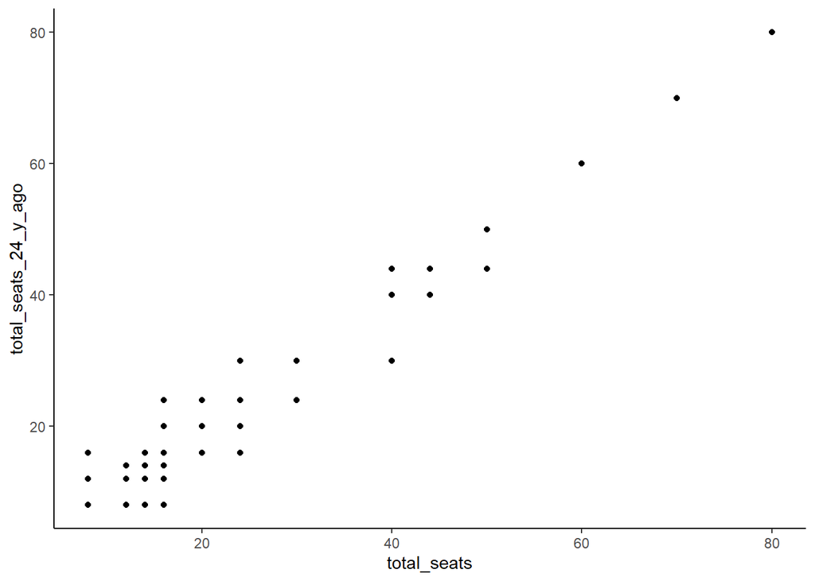

```r
ggplot2::ggplot(data = d_bivariate_iv) + geom_point(aes(total_seats, total_seats_24_y_ago))
```

```r
iv_bivariate <-
  fixest::feols(ln_gross_expenditure_pc ~
                  1 | # 1 is the intercept
                  year + ags | # FE
                  total_seats ~ total_seats_24_y_ago,
                data = d_bivariate_iv)
summary(iv_bivariate, vcov = "hetero", stage = 1:2)
```

```
## IV: First stage: total_seats
## TSLS estimation, Dep. Var.: total_seats, Endo.: total_seats, Instr.: total_seats_24_y_ago
## First stage: Dep. Var.: total_seats
## Observations: 26,639
## Fixed-effects: year: 13,  ags: 2,051
## Standard-errors: Heteroskedasticity-robust
##                      Estimate Std. Error t value Pr(>|t|)
## total_seats_24_y_ago 0.008658   0.004368 1.98213 0.047476 *
## ---
## Signif. codes:  0 '***' 0.001 '**' 0.01 '*' 0.05 '.' 0.1 ' ' 1
## RMSE: 0.360728     Adj. R2: 0.996001
##                  Within R2: 1.609e-4
## F-test (1st stage): stat = 3.95484, p = 0.046748, on 1 and 24,575 DoF.
##
## IV: Second stage
## TSLS estimation, Dep. Var.: ln_gross_expenditure_pc, Endo.: total_seats, Instr.: total_seats_24_y_ago
## Second stage: Dep. Var.: ln_gross_expenditure_pc
## Observations: 26,639
## Fixed-effects: year: 13,  ags: 2,051
## Standard-errors: Heteroskedasticity-robust
##                 Estimate Std. Error t value Pr(>|t|)
## fit_total_seats 0.590465   0.396462 1.48934  0.13641
## ---
## Signif. codes:  0 '***' 0.001 '**' 0.01 '*' 0.05 '.' 0.1 ' ' 1
## RMSE: 0.283661     Adj. R2: 0.193031
##                  Within R2: -1.30718
## F-test (1st stage), total_seats: stat = 3.95677, p = 0.046694, on 1 and 24,587 DoF.
##                      Wu-Hausman: stat = 5.17062, p = 0.022981, on 1 and 24,574 DoF.
```

```r
summary(iv_bivariate, vcov = "twoway", stage = 1:2)
```

```
## IV: First stage: total_seats
## TSLS estimation, Dep. Var.: total_seats, Endo.: total_seats, Instr.: total_seats_24_y_ago
## First stage: Dep. Var.: total_seats
## Observations: 26,639
## Fixed-effects: year: 13,  ags: 2,051
## Standard-errors: Clustered (year & ags)
##                      Estimate Std. Error  t value Pr(>|t|)
## total_seats_24_y_ago 0.008658    0.01026 0.843857  0.41525
## ---
## Signif. codes:  0 '***' 0.001 '**' 0.01 '*' 0.05 '.' 0.1 ' ' 1
## RMSE: 0.360728     Adj. R2: 0.996001
##                  Within R2: 1.609e-4
## F-test (1st stage): stat = 4.28668, p = 0.038422, on 1 and 26,637 DoF.
##
## IV: Second stage
## TSLS estimation, Dep. Var.: ln_gross_expenditure_pc, Endo.: total_seats, Instr.: total_seats_24_y_ago
## Second stage: Dep. Var.: ln_gross_expenditure_pc
## Observations: 26,639
## Fixed-effects: year: 13,  ags: 2,051
## Standard-errors: Clustered (year & ags)
##                 Estimate Std. Error  t value Pr(>|t|)
## fit_total_seats 0.590465   0.746645 0.790824   0.4444
## ---
## Signif. codes:  0 '***' 0.001 '**' 0.01 '*' 0.05 '.' 0.1 ' ' 1
## RMSE: 0.283661     Adj. R2: 0.193031
##                  Within R2: -1.30718
## F-test (1st stage), total_seats: stat = 3.95677, p = 0.046694, on 1 and 24,587 DoF.
##                      Wu-Hausman: stat = 5.17062, p = 0.022981, on 1 and 24,574 DoF.
```

With FE, the effect on the first stage is basically 0. This does not make sense if you look at the relationship between endogenous regressor and instrument. Likely reason: municipality FE, since changes within municipalities occur rarely. This is suggestively confirmed by an IV regression with municipality but not year FE as the effect may be significant but of small magnitude:

```r
iv_bivariate <-
  fixest::feols(ln_gross_expenditure_pc ~
                  1 | # 1 is the intercept
                  ags | # FE
                  total_seats ~ total_seats_24_y_ago,
                data = d_bivariate_iv)
summary(iv_bivariate, vcov = "hetero", stage = 1:2)
```

```
## IV: First stage: total_seats
## TSLS estimation, Dep. Var.: total_seats, Endo.: total_seats, Instr.: total_seats_24_y_ago
## First stage: Dep. Var.: total_seats
## Observations: 26,639
## Fixed-effects: ags: 2,051
## Standard-errors: Heteroskedasticity-robust
##                      Estimate Std. Error t value        Pr(>|t|)
## total_seats_24_y_ago 0.023283   0.004035 5.77075 0.0000000079867 ***
## ---
## Signif. codes:  0 '***' 0.001 '**' 0.01 '*' 0.05 '.' 0.1 ' ' 1
## RMSE: 0.363225     Adj. R2: 0.995948
##                  Within R2: 0.001197
## F-test (1st stage): stat = 29.5, p = 5.736e-8, on 1 and 24,587 DoF.
##
## IV: Second stage
## TSLS estimation, Dep. Var.: ln_gross_expenditure_pc, Endo.: total_seats, Instr.: total_seats_24_y_ago
## Second stage: Dep. Var.: ln_gross_expenditure_pc
## Observations: 26,639
## Fixed-effects: ags: 2,051
## Standard-errors: Heteroskedasticity-robust
##                 Estimate Std. Error t value     Pr(>|t|)
## fit_total_seats  2.15257   0.385563 5.58293 0.0000000239 ***
## ---
## Signif. codes:  0 '***' 0.001 '**' 0.01 '*' 0.05 '.' 0.1 ' ' 1
## RMSE: 0.802718     Adj. R2:  -5.45911
##                  Within R2: -11.1
## F-test (1st stage), total_seats: stat =  31.9, p = 1.618e-8, on 1 and 26,637 DoF.
##                      Wu-Hausman: stat = 333.1, p < 2.2e-16 , on 1 and 24,586 DoF.
```

```r
summary(iv_bivariate, vcov = "cluster", stage = 1:2)
```

```
## IV: First stage: total_seats
## TSLS estimation, Dep. Var.: total_seats, Endo.: total_seats, Instr.: total_seats_24_y_ago
## First stage: Dep. Var.: total_seats
## Observations: 26,639
## Fixed-effects: ags: 2,051
## Standard-errors: Clustered (ags)
##                      Estimate Std. Error t value Pr(>|t|)
## total_seats_24_y_ago 0.023283   0.009971 2.33497 0.019641 *
## ---
## Signif. codes:  0 '***' 0.001 '**' 0.01 '*' 0.05 '.' 0.1 ' ' 1
## RMSE: 0.363225     Adj. R2: 0.995948
##                  Within R2: 0.001197
## F-test (1st stage): stat = 31.9, p = 1.618e-8, on 1 and 26,637 DoF.
##
## IV: Second stage
## TSLS estimation, Dep. Var.: ln_gross_expenditure_pc, Endo.: total_seats, Instr.: total_seats_24_y_ago
## Second stage: Dep. Var.: ln_gross_expenditure_pc
## Observations: 26,639
## Fixed-effects: ags: 2,051
## Standard-errors: Clustered (ags)
##                 Estimate Std. Error t value Pr(>|t|)
## fit_total_seats  2.15257   0.908718  2.3688 0.017938 *
## ---
## Signif. codes:  0 '***' 0.001 '**' 0.01 '*' 0.05 '.' 0.1 ' ' 1
## RMSE: 0.802718     Adj. R2:  -5.45911
##                  Within R2: -11.1
## F-test (1st stage), total_seats: stat =  31.9, p = 1.618e-8, on 1 and 26,637 DoF.
##                      Wu-Hausman: stat = 333.1, p < 2.2e-16 , on 1 and 24,586 DoF.
```

```r
iv_bivariate <-
  fixest::feols(ln_gross_expenditure_pc ~
                  1 | # 1 is the intercept
                  year | # FE
                  total_seats ~ total_seats_24_y_ago,
                data = d_bivariate_iv)
summary(iv_bivariate, vcov = "hetero", stage = 1:2)
```

```
## IV: First stage: total_seats
## TSLS estimation, Dep. Var.: total_seats, Endo.: total_seats, Instr.: total_seats_24_y_ago
## First stage: Dep. Var.: total_seats
## Observations: 26,639
## Fixed-effects: year: 13
## Standard-errors: Heteroskedasticity-robust
##                      Estimate Std. Error t value  Pr(>|t|)
## total_seats_24_y_ago 0.975659   0.001947 501.162 < 2.2e-16 ***
## ---
## Signif. codes:  0 '***' 0.001 '**' 0.01 '*' 0.05 '.' 0.1 ' ' 1
## RMSE: 1.61515     Adj. R2: 0.926004
##                 Within R2: 0.926036
## F-test (1st stage): stat = 333,348.6, p < 2.2e-16, on 1 and 26,625 DoF.
##
## IV: Second stage
## TSLS estimation, Dep. Var.: ln_gross_expenditure_pc, Endo.: total_seats, Instr.: total_seats_24_y_ago
## Second stage: Dep. Var.: ln_gross_expenditure_pc
## Observations: 26,639
## Fixed-effects: year: 13
## Standard-errors: Heteroskedasticity-robust
##                 Estimate Std. Error t value  Pr(>|t|)
## fit_total_seats  0.00692   0.000327 21.1548 < 2.2e-16 ***
## ---
## Signif. codes:  0 '***' 0.001 '**' 0.01 '*' 0.05 '.' 0.1 ' ' 1
## RMSE: 0.297475     Adj. R2: 0.180848
##                  Within R2: 0.013822
## F-test (1st stage), total_seats: stat = 333,498.9, p < 2.2e-16, on 1 and 26,637 DoF.
##                      Wu-Hausman: stat =     112.7, p < 2.2e-16, on 1 and 26,624 DoF.
```

```r
summary(iv_bivariate, vcov = "cluster", stage = 1:2)
```

```
## IV: First stage: total_seats
## TSLS estimation, Dep. Var.: total_seats, Endo.: total_seats, Instr.: total_seats_24_y_ago
## First stage: Dep. Var.: total_seats
## Observations: 26,639
## Fixed-effects: year: 13
## Standard-errors: Clustered (year)
##                      Estimate Std. Error t value  Pr(>|t|)
## total_seats_24_y_ago 0.975659   0.000499 1956.53 < 2.2e-16 ***
## ---
## Signif. codes:  0 '***' 0.001 '**' 0.01 '*' 0.05 '.' 0.1 ' ' 1
## RMSE: 1.61515     Adj. R2: 0.926004
##                 Within R2: 0.926036
## F-test (1st stage): stat = 333,498.9, p < 2.2e-16, on 1 and 26,637 DoF.
##
## IV: Second stage
## TSLS estimation, Dep. Var.: ln_gross_expenditure_pc, Endo.: total_seats, Instr.: total_seats_24_y_ago
## Second stage: Dep. Var.: ln_gross_expenditure_pc
## Observations: 26,639
## Fixed-effects: year: 13
## Standard-errors: Clustered (year)
##                 Estimate Std. Error t value        Pr(>|t|)
## fit_total_seats  0.00692    0.00048 14.4078 0.0000000061546 ***
## ---
## Signif. codes:  0 '***' 0.001 '**' 0.01 '*' 0.05 '.' 0.1 ' ' 1
## RMSE: 0.297475     Adj. R2: 0.180848
##                  Within R2: 0.013822
## F-test (1st stage), total_seats: stat = 333,498.9, p < 2.2e-16, on 1 and 26,637 DoF.
##                      Wu-Hausman: stat =     112.7, p < 2.2e-16, on 1 and 26,624 DoF.
```

Here, we do have an estimate on the instrument that is close to one, which is more plausible. Hence, in the following, I am only using year FE.

## Multivariate IV

```r
fixest::feols(
  ln_gross_expenditure_pc ~
    csw0(inh_tot, pop_over65, unempl_rate, total_area_ha,
         share_working_age, kreisfreie_stadt, stadt, years_since_last_elec) | # controls
    year |#+ ags | # FE
    total_seats ~ total_seats_24_y_ago, # IV formula for 1st stage
  data = data,
  vcov = "cluster"
)
```

```
## NOTE: 205,294 observations removed because of NA values (LHS: 121,429, IV: 15,941/190,929). [This msg only concerns the variables common to all estimations.]
```

```
## The exogenous variables 'years_since_last_elec1', 'years_since_last_elec2' and 3 others have been removed because of collinearity (see $collin.var).
```

```
## Standard-errors: Clustered (year)
## Expl. vars.: 1
##                 Estimate Std. Error t value        Pr(>|t|)
## fit_total_seats  0.00692    0.00048 14.4078 0.0000000061546 ***
## ---
## Expl. vars.: inh_tot
##                    Estimate   Std. Error  t value      Pr(>|t|)
## fit_total_seats 0.005430626 0.0005793510  9.37364 0.00000071708 ***
## inh_tot         0.000000494 0.0000000467 10.57237 0.00000019565 ***
## ---
## Expl. vars.: inh_tot + pop_over65
##                    Estimate   Std. Error  t value      Pr(>|t|)
## fit_total_seats 0.003689767 0.0004979677  7.40965 0.00000816743 ***
## inh_tot         0.000000619 0.0000000482 12.84031 0.00000002267 ***
## pop_over65      0.864275991 0.0952651456  9.07232 0.00000101453 ***
## ---
## Expl. vars.: inh_tot + pop_over65 + unempl_rate
##                     Estimate   Std. Error   t value       Pr(>|t|)
## fit_total_seats  0.004496998 0.0005154073   8.72514 0.000001530114 ***
## inh_tot          0.000000597 0.0000000466  12.80940 0.000000023292 ***
## pop_over65       1.074179235 0.1105778521   9.71423 0.000000489436 ***
## unempl_rate     -1.264549021 0.1169025991 -10.81712 0.000000152309 ***
## ---
## Expl. vars.: inh_tot + pop_over65 + unempl_rate + total_area_ha
##                     Estimate   Std. Error   t value       Pr(>|t|)
## fit_total_seats  0.005489507 0.0005148318  10.66272 0.000000178273 ***
## inh_tot          0.000000635 0.0000000474  13.40536 0.000000013951 ***
## pop_over65       1.100916305 0.1128394838   9.75648 0.000000467136 ***
## unempl_rate     -1.280893144 0.1174891603 -10.90222 0.000000139762 ***
## total_area_ha   -0.000004675 0.0000004552 -10.27053 0.000000268199 ***
## ---
## Expl. vars.: inh_tot + pop_over65 + unempl_rate + total_area_ha + share_working_age
##                       Estimate   Std. Error   t value       Pr(>|t|)
## fit_total_seats    0.005237185 0.0005640868   9.28436 0.000000793999 ***
## inh_tot            0.000000635 0.0000000480  13.24436 0.000000015991 ***
## pop_over65         1.241135823 0.1499900346   8.27479 0.000002656404 ***
## unempl_rate       -1.324601638 0.1159030895 -11.42853 0.000000083129 ***
## total_area_ha     -0.000004420 0.0000003729 -11.85100 0.000000055576 ***
## share_working_age  0.243817151 0.1253785439   1.94465 0.075629590783 .
## ---
```

[output cut: 16 more lines]

```
## total_area_ha     -0.000002198 0.0000004125  -5.328815 0.0001796969459750 ***
## share_working_age  0.383323282 0.1612902353   2.376606 0.0349783289138099 *
## kreisfreie_stadt1  0.451575575 0.0159767070  28.264621 0.0000000000023845 ***
## stadt1             0.046937251 0.0034929078  13.437873 0.0000000135740898 ***
## ---
## Expl. vars.: inh_tot + pop_over65 + unempl_rate + total_area_ha + share_working_age + kreisfreie_stadt + stadt + years_since_last_elec
##                       Estimate   Std. Error    t value           Pr(>|t|)
## fit_total_seats   -0.000565308 0.0007339480  -0.770229 0.4560601729344557
## inh_tot            0.000000405 0.0000000378  10.712197 0.0000001694693820 ***
## pop_over65         1.354140751 0.1588955740   8.522206 0.0000019566724175 ***
## unempl_rate       -1.757010019 0.1098479453 -15.994928 0.0000000018607058 ***
## total_area_ha     -0.000002198 0.0000004125  -5.328815 0.0001796969459750 ***
## share_working_age  0.383323282 0.1612902353   2.376606 0.0349783289138099 *
## kreisfreie_stadt1  0.451575575 0.0159767070  28.264621 0.0000000000023845 ***
## stadt1             0.046937251 0.0034929078  13.437873 0.0000000135740898 ***
```

```r
cor(d_controls_iv$total_seats, d_controls_iv$total_seats_24_y_ago)
```

```
## [1] 0.9622348
```

```r
# Model with time and year FE
iv_multivariate <- fixest::feols(
  ln_gross_expenditure_pc ~
    inh_tot + pop_over65 + unempl_rate + total_area_ha +
    share_working_age + kreisfreie_stadt + stadt + years_since_last_elec | # controls
    year + ags | # FE
    total_seats ~ total_seats_24_y_ago, # IV formula for 1st stage
  data = d_controls_iv
)
```

```
## The exogenous variables 'kreisfreie_stadt1', 'stadt1' and 13 others have been removed because of collinearity (see $collin.var).
```

```r
summary(iv_multivariate, vcov = "twoway", stage = 1:2)
```

```
## IV: First stage: total_seats
## TSLS estimation, Dep. Var.: total_seats, Endo.: total_seats, Instr.: total_seats_24_y_ago
## First stage: Dep. Var.: total_seats
## Observations: 26,639
## Fixed-effects: year: 13,  ags: 2,051
## Standard-errors: Clustered (year & ags)
##                         Estimate Std. Error   t value   Pr(>|t|)
## total_seats_24_y_ago  0.00464400 0.01039378  0.446806 0.66297214
## inh_tot               0.00000146 0.00000248  0.587536 0.56773527
## pop_over65           -1.77235091 1.05305316 -1.683059 0.11817715
## unempl_rate           4.83600389 1.10849287  4.362684 0.00092399 ***
## total_area_ha        -0.00006474 0.00005684 -1.139041 0.27691414
## share_working_age    -1.40247338 0.95622834 -1.466672 0.16817682
## ... 15 variables were removed because of collinearity (kreisfreie_stadt1, stadt1 and 13 others [full set in $collin.var])
## ---
## Signif. codes:  0 '***' 0.001 '**' 0.01 '*' 0.05 '.' 0.1 ' ' 1
## RMSE: 0.359345     Adj. R2: 0.996031
##                  Within R2: 0.007813
## F-test (1st stage): stat = 1.22311, p = 0.268761, on 1 and 26,632 DoF.
##
## IV: Second stage
## TSLS estimation, Dep. Var.: ln_gross_expenditure_pc, Endo.: total_seats, Instr.: total_seats_24_y_ago
## Second stage: Dep. Var.: ln_gross_expenditure_pc
## Observations: 26,639
## Fixed-effects: year: 13,  ags: 2,051
## Standard-errors: Clustered (year & ags)
##                      Estimate Std. Error   t value Pr(>|t|)
## fit_total_seats    0.86716499 1.96223178  0.441928  0.66640
## inh_tot           -0.00000335 0.00000405 -0.825941  0.42495
## pop_over65         2.29307568 3.41003343  0.672450  0.51404
## unempl_rate       -4.02609962 9.47940464 -0.424721  0.67856
## total_area_ha      0.00003479 0.00013792  0.252242  0.80512
## share_working_age  1.29233671 2.90248695  0.445252  0.66406
## ... 15 variables were removed because of collinearity (kreisfreie_stadt1, stadt1 and 13 others [full set in $collin.var])
## ---
## Signif. codes:  0 '***' 0.001 '**' 0.01 '*' 0.05 '.' 0.1 ' ' 1
## RMSE: 0.363733     Adj. R2: -0.327128
##                  Within R2: -2.79357
## F-test (1st stage), total_seats: stat =  1.12896, p = 0.288007, on 1 and 24,582 DoF.
##                      Wu-Hausman: stat = NA      , p = NA      , on 1 and 24,569 DoF.
```

```r
# "Real" model
iv_multivariate <- fixest::feols(
  ln_gross_expenditure_pc ~
    inh_tot + pop_over65 + unempl_rate + total_area_ha +
    share_working_age + kreisfreie_stadt + stadt + years_since_last_elec | # controls
    year |#+ ags | # FE
    total_seats ~ total_seats_24_y_ago, # IV formula for 1st stage
  data = d_controls_iv
)
```

```
## The exogenous variables 'years_since_last_elec1', 'years_since_last_elec2' and 11 others have been removed because of collinearity (see $collin.var).
```

```r
summary(iv_multivariate, vcov = "hetero", stage = 1:2)
```

```
## IV: First stage: total_seats
## TSLS estimation, Dep. Var.: total_seats, Endo.: total_seats, Instr.: total_seats_24_y_ago
## First stage: Dep. Var.: total_seats
## Observations: 26,639
## Fixed-effects: year: 13
## Standard-errors: Heteroskedasticity-robust
##                          Estimate  Std. Error    t value               Pr(>|t|)
## total_seats_24_y_ago   0.98509852 0.003847122 256.061187              < 2.2e-16
## inh_tot                0.00000197 0.000000554   3.549519 0.00038660030168690681
## pop_over65           -10.35193343 0.493137773 -20.991970              < 2.2e-16
## unempl_rate           -7.38407937 0.862219131  -8.564040              < 2.2e-16
## total_area_ha         -0.00000204 0.000004759  -0.427769 0.66882245595272160621
## share_working_age      2.90704641 0.627564348   4.632268 0.00000363391632851485
## kreisfreie_stadt1      0.09654886 0.136732641   0.706114 0.48012332023838211192
## stadt1                 0.31996494 0.039307502   8.140048 0.00000000000000041224
##
## total_seats_24_y_ago ***
## inh_tot              ***
## pop_over65           ***
## unempl_rate          ***
## total_area_ha
## share_working_age    ***
## kreisfreie_stadt1
## stadt1               ***
## ... 13 variables were removed because of collinearity (years_since_last_elec1, years_since_last_elec2 and 11 others [full set in $collin.var])
## ---
## Signif. codes:  0 '***' 0.001 '**' 0.01 '*' 0.05 '.' 0.1 ' ' 1
## RMSE: 1.5636     Adj. R2: 0.930634
##                Within R2: 0.930683
## F-test (1st stage): stat = 120,580.0, p < 2.2e-16, on 1 and 26,618 DoF.
##
## IV: Second stage
## TSLS estimation, Dep. Var.: ln_gross_expenditure_pc, Endo.: total_seats, Instr.: total_seats_24_y_ago
## Second stage: Dep. Var.: ln_gross_expenditure_pc
## Observations: 26,639
## Fixed-effects: year: 13
## Standard-errors: Heteroskedasticity-robust
##                       Estimate   Std. Error   t value               Pr(>|t|)
## fit_total_seats   -0.000565308 0.0005564885  -1.01585 0.30971047641790355742
## inh_tot            0.000000405 0.0000000363  11.14662              < 2.2e-16
## pop_over65         1.354140751 0.1035450592  13.07779              < 2.2e-16
## unempl_rate       -1.757010019 0.1553295823 -11.31150              < 2.2e-16
## total_area_ha     -0.000002198 0.0000009015  -2.43839 0.01475916566214174712
## share_working_age  0.383323282 0.1427203627   2.68583 0.00723937722362642724
## kreisfreie_stadt1  0.451575575 0.0199663873  22.61679              < 2.2e-16
## stadt1             0.046937251 0.0057937987   8.10129 0.00000000000000056689
##
## fit_total_seats
## inh_tot           ***
## pop_over65        ***
## unempl_rate       ***
## total_area_ha     *
## share_working_age **
## kreisfreie_stadt1 ***
## stadt1            ***
## ... 13 variables were removed because of collinearity (years_since_last_elec1, years_since_last_elec2 and 11 others [full set in $collin.var])
## ---
## Signif. codes:  0 '***' 0.001 '**' 0.01 '*' 0.05 '.' 0.1 ' ' 1
## RMSE: 0.292775     Adj. R2: 0.206322
##                  Within R2: 0.044741
## F-test (1st stage), total_seats: stat = 120,634.4, p < 2.2e-16, on 1 and 26,630 DoF.
##                      Wu-Hausman: stat =      NA  , p = NA     , on 1 and 26,617 DoF.
```

```r
summary(iv_multivariate, vcov = "cluster", stage = 1:2)
```

```
## IV: First stage: total_seats
## TSLS estimation, Dep. Var.: total_seats, Endo.: total_seats, Instr.: total_seats_24_y_ago
## First stage: Dep. Var.: total_seats
## Observations: 26,639
## Fixed-effects: year: 13
## Standard-errors: Clustered (year)
##                          Estimate   Std. Error    t value            Pr(>|t|)
## total_seats_24_y_ago   0.98509852 0.0039822864 247.370082           < 2.2e-16
## inh_tot                0.00000197 0.0000000635  30.930150 0.00000000000081969
## pop_over65           -10.35193343 0.7541465383 -13.726687 0.00000001067033494
## unempl_rate           -7.38407937 0.4240283067 -17.414119 0.00000000069769092
## total_area_ha         -0.00000204 0.0000040721  -0.499966 0.62614039916199338
## share_working_age      2.90704641 2.1491203518   1.352668 0.20110016419163509
## kreisfreie_stadt1      0.09654886 0.0798362411   1.209336 0.24982097367377273
## stadt1                 0.31996494 0.0320700478   9.977065 0.00000036712668453
##
## total_seats_24_y_ago ***
## inh_tot              ***
## pop_over65           ***
## unempl_rate          ***
## total_area_ha
## share_working_age
## kreisfreie_stadt1
## stadt1               ***
## ... 13 variables were removed because of collinearity (years_since_last_elec1, years_since_last_elec2 and 11 others [full set in $collin.var])
## ---
## Signif. codes:  0 '***' 0.001 '**' 0.01 '*' 0.05 '.' 0.1 ' ' 1
## RMSE: 1.5636     Adj. R2: 0.930634
##                Within R2: 0.930683
## F-test (1st stage): stat = 120,634.4, p < 2.2e-16, on 1 and 26,630 DoF.
##
## IV: Second stage
## TSLS estimation, Dep. Var.: ln_gross_expenditure_pc, Endo.: total_seats, Instr.: total_seats_24_y_ago
## Second stage: Dep. Var.: ln_gross_expenditure_pc
## Observations: 26,639
## Fixed-effects: year: 13
## Standard-errors: Clustered (year)
##                       Estimate   Std. Error    t value           Pr(>|t|)
## fit_total_seats   -0.000565308 0.0007339480  -0.770229 0.4560601729344557
## inh_tot            0.000000405 0.0000000378  10.712197 0.0000001694693820 ***
## pop_over65         1.354140751 0.1588955740   8.522206 0.0000019566724175 ***
## unempl_rate       -1.757010019 0.1098479453 -15.994928 0.0000000018607058 ***
## total_area_ha     -0.000002198 0.0000004125  -5.328815 0.0001796969459750 ***
## share_working_age  0.383323282 0.1612902353   2.376606 0.0349783289138099 *
## kreisfreie_stadt1  0.451575575 0.0159767070  28.264621 0.0000000000023845 ***
## stadt1             0.046937251 0.0034929078  13.437873 0.0000000135740898 ***
## ... 13 variables were removed because of collinearity (years_since_last_elec1, years_since_last_elec2 and 11 others [full set in $collin.var])
## ---
## Signif. codes:  0 '***' 0.001 '**' 0.01 '*' 0.05 '.' 0.1 ' ' 1
## RMSE: 0.292775     Adj. R2: 0.206322
##                  Within R2: 0.044741
## F-test (1st stage), total_seats: stat = 120,634.4, p < 2.2e-16, on 1 and 26,630 DoF.
##                      Wu-Hausman: stat =      NA  , p = NA     , on 1 and 26,617 DoF.
```

```r
-0.000565308 + c(1.96, -1.96) * 0.0007339480 # CI for total_seats in the latter case
```

```
## [1]  0.0008732301 -0.0020038461
```

```r
# Run it again with clustered SE for summary
iv_multivariate <- fixest::feols(
  ln_gross_expenditure_pc ~
    inh_tot + pop_over65 + unempl_rate + total_area_ha +
    share_working_age + kreisfreie_stadt + stadt + years_since_last_elec | # controls
    year |#+ ags | # FE
    total_seats ~ total_seats_24_y_ago, # IV formula for 1st stage
  vcov = "cluster",
  data = d_controls_iv
)
```

```
## The exogenous variables 'years_since_last_elec1', 'years_since_last_elec2' and 11 others have been removed because of collinearity (see $collin.var).
```

[“Wu-Hausman tests that IV is just as consistent as OLS, and since OLS is more efficient, it would be preferable. The null here is that they are equally consistent”](https://stats.stackexchange.com/questions/134789/interpretation-of-ivreg-diagnostics-in-r). E. g. if the null is rejected at the 10 % level, this is “good” from the IV perspective.

# Summary of conventional-methods results

```r
etable(ols, panel_bivariate, panel_multivariate, iv_multivariate)
```

|  | ols | panel_bivariate | panel_multivariate | iv_multivariate |
| --- | --- | --- | --- | --- |
| Dependent Var.: | ln_gross_expenditure_pc | ln_gross_expenditure_pc | ln_gross_expenditure_pc | ln_gross_expenditure_pc |
| (Intercept) | 7.132*** (0.0403) |  |  |  |
| total_seats | 0.0081*** (0.0002) | 0.0023. (0.0011) | 0.0025* (0.0011) | -0.0006 (0.0007) |
| inh_tot | -1.92e-7*** (4.02e-8) |  | -2.55e-6* (1.15e-6) | 4.05e-7*** (3.78e-8) |
| pop_over65 | 0.2671*** (0.0449) |  | 0.8016*** (0.1703) | 1.354*** (0.1589) |
| unempl_rate | -2.932*** (0.0411) |  | 0.2074 (0.1223) | -1.757*** (0.1098) |
| total_area_ha | 1.68e-5*** (4.98e-7) |  | 6e-6 (6.45e-6) | -2.2e-6*** (4.12e-7) |
| share_working_age | -0.0468 (0.0569) |  | 0.2515. (0.1358) | 0.3833* (0.1613) |
| kreisfreie_stadt1 | 0.4139*** (0.0105) |  |  | 0.4516*** (0.0160) |

[output cut: 14 more lines]

Test LaTeX export – note that differences between HTML and TeX output remain.

```r
# etable(ols, panel_bivariate, panel_multivariate,
#        # Table settings
#        drop = "!Council size",
#        dict = c(total_seats = "Council size",
#                 ln_gross_expenditure_pc = "Ln of gross expenditure p. c."),
#        signif.code = c("***"=0.001, "**"=0.01, "*"=0.05, "'"=0.10),
#        headers = list("OLS", "FE bivariate", "FE multivariate"),
#        # LaTeX settings
#        title = "Results of the \"Conventional\" Regression Methods",
#        label = "tab:conv_results",
#        notes = "Test notes here",
#        style.df = style.df(
#          fixef.suffix = " fixed-effect"
#        )
#        )
```

## Export to LaTeX

```r
etable(ols, panel_bivariate, panel_multivariate, iv_multivariate,
       file = "tables/conv_results.tex",
       replace = TRUE,
       # Table settings
       drop = "!Council size",
       dict = c(total_seats = "Council size",
                ln_gross_expenditure_pc = "Ln of gross expenditure p. c."),
       signif.code = c("***"=0.001, "**"=0.01, "*"=0.05, "'"=0.10),
       headers = c("\\acs{OLS}", "\\acs{FE} bivariate", "\\acs{FE} multivariate", "\\acs{IV} multivariate"),
       extralines = list(
         "-^Controls" = c("Yes", "No", "Yes", "Yes"),
         "-_\\acs{SE}" = c("\\acs{het}", "by \\acs{yr} & \\acs{mcp}", "by \\acs{yr} & \\acs{mcp}", "by \\acs{yr}"),
         "_^Data sample" = c(rep("All data", 3), "\\acs{BY} only")
         ),
       # LaTeX settings
       title = "Results of the ``Conventional'' Regression Methods",
       label = "tab:conv_results",
       notes = paste("\\footnotesize{*Notes:* Results of the ``conventional'' regression methods.",
                     tex_control_text,
                     "The \\acl{SE} in parentheses: \\ac{het}; if \\ac{SE} starts with ``by'', they are clustered at the \\ac{yr} and/or \\ac{mcp} level.",
                     tex_signif_text),
       style.tex = style.tex(
         fixef.suffix = " \\ac{FE}"
       )
       )
```

```r
rm(list=ls(pattern="^panel_"))
rm(list=ls(pattern="^iv_"))
```

# Concluding Remarks

For references, see the paper.

```r
Sys.time() - time
```

```
## Time difference of 16.91772 secs
```